# State MSM Profile: **North Carolina**

#### New Bern Metropolitan Statistical Area

The New Bern MSA had a population of 711 MSM, or 0.7% of all MSM in North Carolina. Of the 49,475 adult men in New Bern, an estimated 1.4% were MSM.

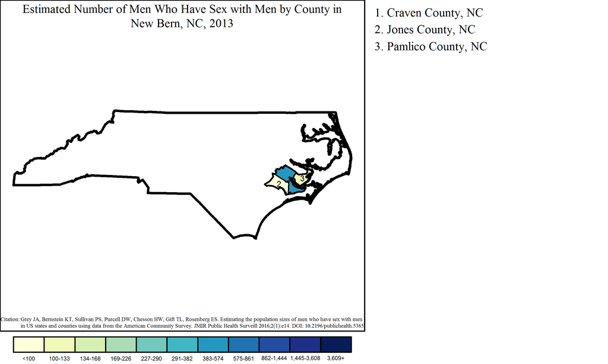

Note: Range cutpoints for the map are based on the distribution of MSM among all counties in the United States.

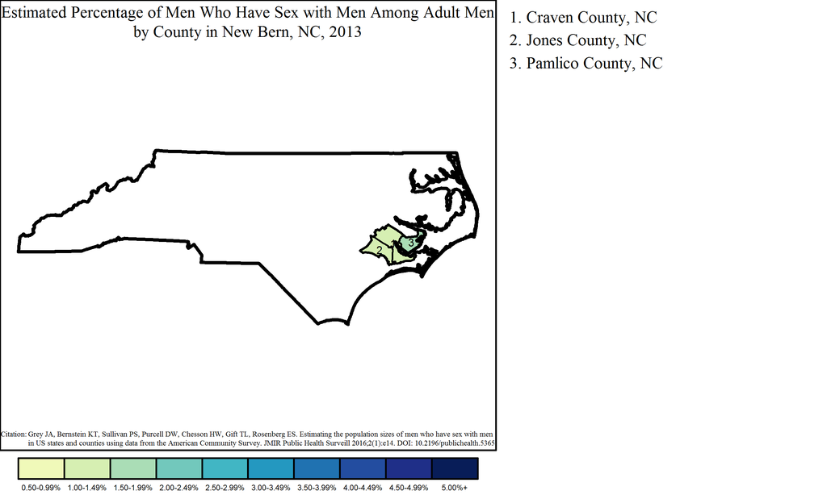

#### Goldsboro Metropolitan Statistical Area

The Goldsboro MSA had a population of 654 MSM, or 0.6% of all MSM in North Carolina. Of the 44,881 adult men in Goldsboro, an estimated 1.5% were MSM.

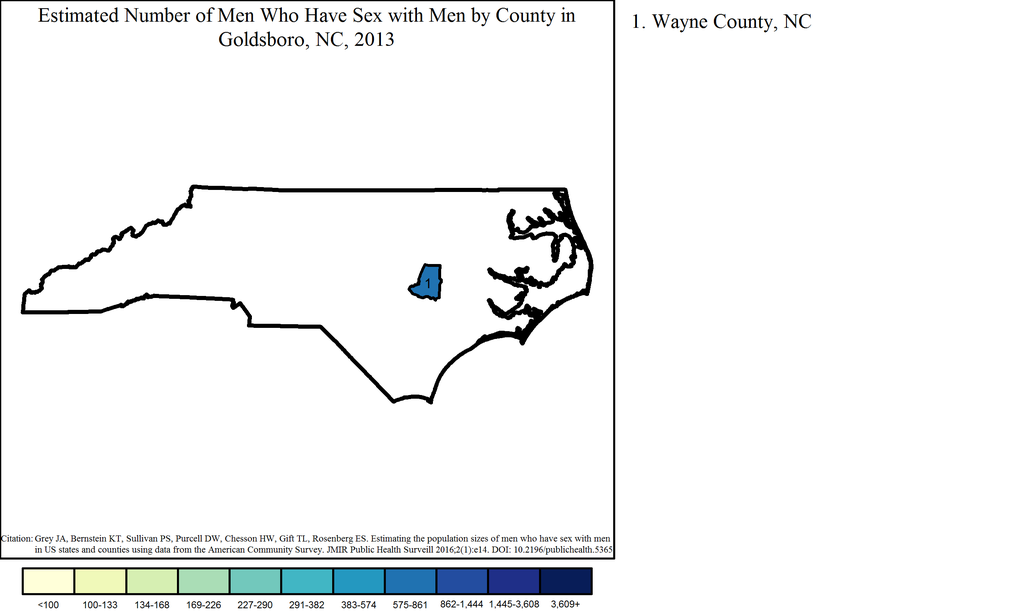

Note: Range cutpoints for the map are based on the distribution of MSM among all counties in the United States.

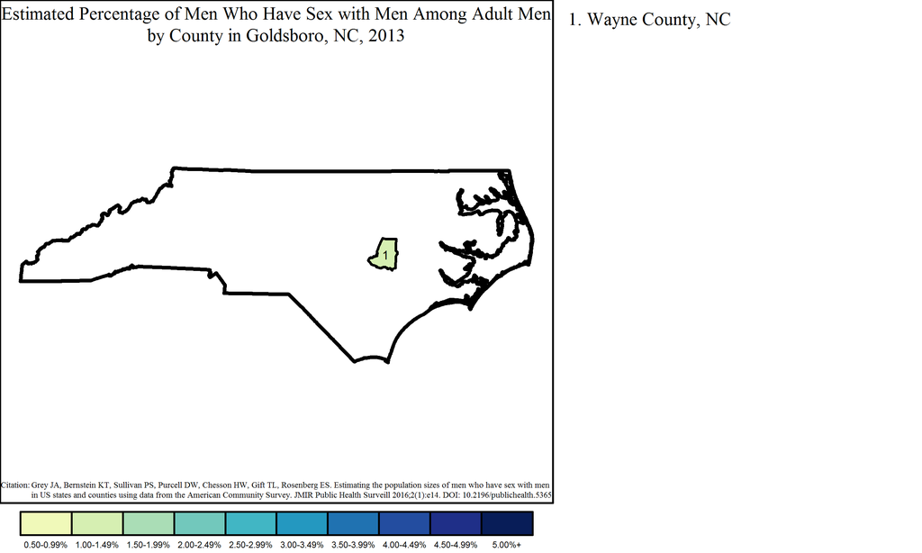

#### Virginia Beach-Norfolk-Newport News Metropolitan Statistical Area

The Virginia Beach-Norfolk-Newport News MSA overlaps two states: North Carolina and Virginia. The North Carolina portion of the MSA had 457 MSM, or 0.4% of all MSM in the state and 1.8% of the 24,875 MSM in the MSA. Of 13,527 adult men in the North Carolina part of Virginia Beach-Norfolk-Newport News, 3.4% were MSM. This was less than the overall percentage of MSM among adult men in the MSA, which was 4.0% of adult men (24,875 out of 629,402).

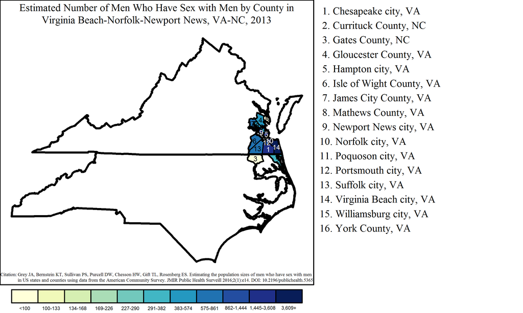

Note: Range cutpoints for the map are based on the distribution of MSM among all counties in the United States.

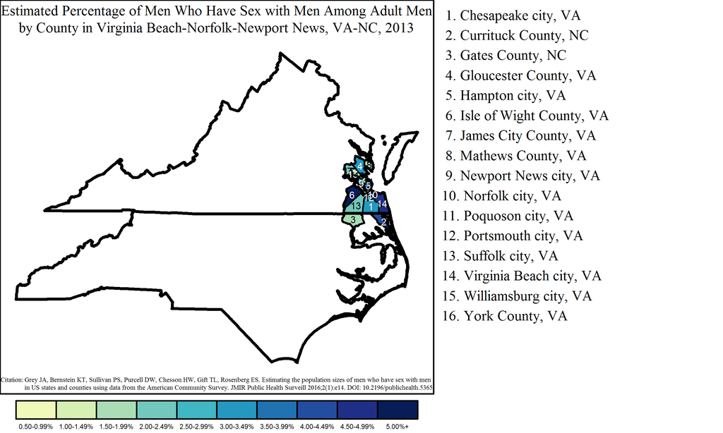